# Assignment 3: build a tariff plan

Students:

- Dzmitry Sei, r0913246
- 1 Libraries
- 2 Feature engineering and EDA
  - 2.1 Mapping text columns to categorical
  - 2.2 Transforming exposure
  - 2.3 Handling postal code
    - 2.3.1 Clustering of the datapoints
  - 2.4 EDA
  - 2.5 Feature columns
  - 2.6 Train/test split
- 3 XGBoost
  - 3.1 Frequency prediction
    - 3.1.1 Model building
    - 3.1.2 Interpretation
  - 3.2 Severity prediction
    - 3.2.1 Model building
    - 3.2.2 Interpretation
  - 3.3 Caluclations safety demonstration
  - 3.4 Risk loading
    - 3.4.1 Expected value principle
    - 3.4.2 Theta calculation
  - 3.5 Final model perfomance on the test data
    - 3.5.1 Final model probability of ruin
- 4 Random forest
  - 4.1 Frequency prediction
    - 4.1.1 Model building
    - 4.1.2 Interpretation
  - 4.2 Severity prediction
    - 4.2.1 Model building
    - 4.2.2 Interpretation
  - 4.3 Caluclations safety demonstration
  - 4.4 Risk loading
    - 4.4.1 Theta calculation
  - 4.5 Final model perfomance on the test data
    - 4.5.1 Final model probability of ruin

## 1 Libraries

```python
import random
import pandas as pd
import numpy as np
import xgboost as xgb
import matplotlib.pyplot as plt

from sklearn.preprocessing import StandardScaler
from sklearn.model_selection import train_test_split, GridSearchCV, RandomizedSearchCV
from sklearn.cluster import KMeans
from sklearn.inspection import PartialDependenceDisplay
from sklearn.ensemble import RandomForestRegressor
from scipy.stats import norm
import scipy.stats as stats

random.seed(0)
np.random.seed(0)
```

```python
data = pd.read_csv('Assignment.csv')
data.head()
```

|  | AGEPH | CODPOSS | duree | lnexpo | nbrtotc | nbrtotan | chargtot | agecar | sexp | fuelc | split | usec | fleetc | sportc | coverp | powerc |
| --- | --- | --- | --- | --- | --- | --- | --- | --- | --- | --- | --- | --- | --- | --- | --- | --- |
| 0 | 64 | 1000 | 1.000000 | 0.000000 | 0 | 0.000000 | 0.000000 | 2-5 | Female | Petrol | Once | Private | No | No | MTPL+ | 66-110 |
| 1 | 28 | 1000 | 0.046575 | -3.066684 | 1 | 21.470588 | 155.974606 | 6-10 | Female | Petrol | Twice | Private | No | No | MTPL | 66-110 |
| 2 | 58 | 1000 | 0.402740 | -0.909465 | 0 | 0.000000 | 0.000000 | >10 | Female | Petrol | Thrice | Private | No | No | MTPL | <66 |
| 3 | 37 | 1030 | 0.169863 | -1.772763 | 0 | 0.000000 | 0.000000 | 2-5 | Female | Petrol | Once | Professional | No | No | MTPL+++ | 66-110 |
| 4 | 29 | 1030 | 1.000000 | 0.000000 | 0 | 0.000000 | 0.000000 | 6-10 | Female | Petrol | Once | Private | No | No | MTPL+ | <66 |

## 2 Feature engineering and EDA

### 2.1 Mapping text columns to categorical

The mapping is made to a signle column, and not to a vector, because all the string columns have internal ordering structure.

```python
data['agecar'] =  data['agecar'].map({'0-1': 0, '2-5': 1, '6-10': 2, '>10': 3})
data['sexp'] =  data['sexp'].map({'Female': 0, 'Male':1})
data['fuelc'] = data['fuelc'].map({'Petrol': 0, 'Gasoil': 1})
data['split'] = data['split'].map({'Once': 0, 'Twice': 1, 'Thrice': 2, 'Monthly': 3})
data['usec'] = data['usec'].map({'Private': 0, 'Professional': 1})
data['fleetc'] = data['fleetc'].map({'No': 0, 'Yes': 1})
data['sportc'] = data['sportc'].map({'No': 0, 'Yes': 1})
data['coverp'] = data['coverp'].map({'MTPL': 0, 'MTPL+': 1, 'MTPL+++': 2})
data['powerc'] = data['powerc'].map({'<66': 0, '66-110': 1, '>110': 2})
```

### 2.2 Transforming exposure

```python
data['expo'] =  data['lnexpo'].apply(np.exp)
```

### 2.3 Handling postal code

```python
geo_data =  pd.read_excel('inspost.xls')
df1 = data[['CODPOSS']]
df2 = geo_data[['CODPOSS', 'LAT', 'LONG']]
mapped_geodata = pd.merge(df1, df2, on='CODPOSS', how='left')

mapped_geodata.head()
```

|  | CODPOSS | LAT | LONG |
| --- | --- | --- | --- |
| 0 | 1000 | 50.833333 | 4.350000 |
| 1 | 1000 | 50.833333 | 4.350000 |
| 2 | 1000 | 50.833333 | 4.350000 |
| 3 | 1030 | 50.850000 | 4.383333 |
| 4 | 1030 | 50.850000 | 4.383333 |

#### 2.3.1 Clustering of the datapoints

The idea is to divide the data into categories, which are close in location (LAT and LONG) and in loss per exposure.

Since the categories can't be ordered, one-hot encoding approach is used to transform the clusters into vectors

```python
clustering_df = pd.DataFrame({
    'LAT': mapped_geodata['LAT'],
    'LONG': mapped_geodata['LONG'],
    'loss': data['chargtot'] / data['expo'] # Proxy to the technical premium
})

X_scaled = StandardScaler().fit_transform(clustering_df[['LAT', 'LONG', 'loss']])

N_CLUSTERS = 4
kmeans = KMeans(n_clusters=N_CLUSTERS, random_state = 32)
kmeans.fit(X_scaled)

ONE_HOT_PREFIX = 'loc_category'
ONE_HOT_SEP = '_'
one_hot = pd.get_dummies(kmeans.labels_, prefix=ONE_HOT_PREFIX, prefix_sep=ONE_HOT_SEP)

data = pd.concat([data, one_hot], axis=1)
```

```python
data
```

|  | AGEPH | CODPOSS | duree | lnexpo | nbrtotc | nbrtotan | chargtot | agecar | sexp | fuelc | ... | usec | fleetc | sportc | coverp | powerc | expo | loc_category_0 | loc_category_1 | loc_category_2 | loc_category_3 |
| --- | --- | --- | --- | --- | --- | --- | --- | --- | --- | --- | --- | --- | --- | --- | --- | --- | --- | --- | --- | --- | --- |
| 0 | 64 | 1000 | 1.000000 | 0.000000 | 0 | 0.000000 | 0.000000 | 1 | 0 | 0 | ... | 0 | 0 | 0 | 1 | 1 | 1.000000 | 0 | 1 | 0 | 0 |
| 1 | 28 | 1000 | 0.046575 | -3.066684 | 1 | 21.470588 | 155.974606 | 2 | 0 | 0 | ... | 0 | 0 | 0 | 0 | 1 | 0.046575 | 0 | 1 | 0 | 0 |
| 2 | 58 | 1000 | 0.402740 | -0.909465 | 0 | 0.000000 | 0.000000 | 3 | 0 | 0 | ... | 0 | 0 | 0 | 0 | 0 | 0.402740 | 0 | 1 | 0 | 0 |
| 3 | 37 | 1030 | 0.169863 | -1.772763 | 0 | 0.000000 | 0.000000 | 1 | 0 | 0 | ... | 1 | 0 | 0 | 2 | 1 | 0.169863 | 0 | 1 | 0 | 0 |
| 4 | 29 | 1030 | 1.000000 | 0.000000 | 0 | 0.000000 | 0.000000 | 2 | 0 | 0 | ... | 0 | 0 | 0 | 1 | 0 | 1.000000 | 0 | 1 | 0 | 0 |
| ... | ... | ... | ... | ... | ... | ... | ... | ... | ... | ... | ... | ... | ... | ... | ... | ... | ... | ... | ... | ... | ... |
| 163652 | 50 | 9960 | 1.000000 | 0.000000 | 0 | 0.000000 | 0.000000 | 1 | 1 | 0 | ... | 0 | 0 | 0 | 1 | 0 | 1.000000 | 0 | 1 | 0 | 0 |
| 163653 | 86 | 9960 | 1.000000 | 0.000000 | 0 | 0.000000 | 0.000000 | 2 | 1 | 0 | ... | 0 | 0 | 0 | 0 | 0 | 1.000000 | 0 | 1 | 0 | 0 |
| 163654 | 64 | 9960 | 1.000000 | 0.000000 | 0 | 0.000000 | 0.000000 | 1 | 1 | 0 | ... | 0 | 0 | 0 | 0 | 0 | 1.000000 | 0 | 1 | 0 | 0 |
| 163655 | 58 | 9970 | 1.000000 | 0.000000 | 1 | 1.000000 | 3177.994988 | 3 | 1 | 0 | ... | 0 | 1 | 0 | 0 | 0 | 1.000000 | 0 | 1 | 0 | 0 |
| 163656 | 24 | 9990 | 1.000000 | 0.000000 | 2 | 2.000000 | 13818.229594 | 1 | 1 | 0 | ... | 0 | 0 | 0 | 2 | 0 | 1.000000 | 0 | 1 | 0 | 0 |

163657 rows × 21 columns

### 2.4 EDA

Overall the data is clean.

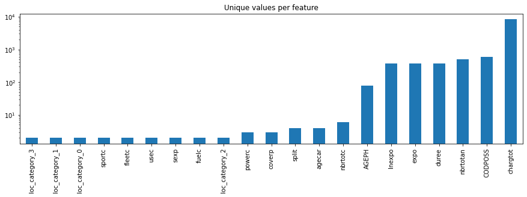

```python
unique_values = data.select_dtypes(include="number").nunique().sort_values()
unique_values.plot.bar(logy=True, figsize=(15, 4), title="Unique values per feature");
```

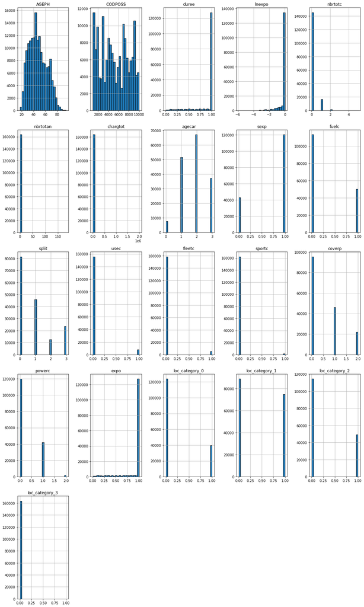

```python
data.hist(bins=25, figsize=(15, 25), layout=(-1, 5), edgecolor="black")
plt.tight_layout();
```

### 2.5 Feature columns

```python
feat_cols = ['agecar','sexp','fuelc','split','usec','fleetc','sportc','coverp', 'powerc', 'AGEPH'] + [
    f'{ONE_HOT_PREFIX}{ONE_HOT_SEP}{i}' for i in range(N_CLUSTERS)
]

categorical_feat_cols = list(set(feat_cols) - set(['AGEPH']))
```

### 2.6 Train/test split

To avoid disbalance in the data the split was stratified to $nbrtotc>0$.

Test set will be used for pricing adjustment.

```python
X = data[feat_cols].copy()
#X['claims_pistive'] = data['nbrtotc'] > 0
y = data[['nbrtotc', 'chargtot', 'expo']]

X_train, X_test, y_train, y_test = train_test_split(X, y, test_size=0.2, stratify=data['nbrtotc'] > 0, random_state=42)
X_train, X_val, y_train, y_val = train_test_split(X_train, y_train, test_size=0.2, stratify=y_train['nbrtotc'] > 0, random_state=42)
```

## 3 XGBoost

In this section XGboost-based models will be used to predict frequency and severety. Than the built models will be analysed.

```python
def get_feat_importance(tree_based_alg, X):

    # Get the feature importances
    importances = tree_based_alg.feature_importances_

    # Create a dataframe to store the feature importances
    feature_importances = pd.DataFrame({'feature': X.columns, 'importance': importances})

    # Sort the dataframe by importance
    feature_importances = feature_importances.sort_values(by='importance', ascending=False)


    plt.figure(figsize=(10, 6))

    # Plot the feature importances
    plt.bar(feature_importances['feature'], feature_importances['importance'])
    plt.xticks(rotation=90)
    plt.xlabel('Feature')
    plt.ylabel('Importance')
    plt.title('Feature Importance')
    plt.show()

    return pd.DataFrame(
        {
            'feature':tree_based_alg.feature_names_in_,
            'importance':tree_based_alg.feature_importances_
        }
    ).sort_values('importance', ascending=False)
```

### 3.1 Frequency prediction

Target variable is average amount of claims per unit of exposure $\frac{N_i}{d_i}$,

where $N_i$ - number of claims during the period of exposure $d_i$.

```python
X_freq_train = X_train.copy()
y_freq_train = y_train['nbrtotc'] / y_train['expo']
w_freq_train = y_train['expo']
```

#### 3.1.1 Model building

During model building process randomised grid search was used, to increase the code speed. Poisson deviance based scoring function is used, because of the distribution, of the frequency target variable.

```python
param_dict_xgb = {'max_depth' : [1, 3, 5, 7, 9],
              'n_estimators' : [100, 200, 300],
              'colsample_bynode' : [0.5, 0.75, 1],
              'lambda' : [0, 0.1, 1],
              'alpha' : [0, 0.1, 1]}

xgb_init_freq = xgb.XGBRegressor(booster='gbtree',
                            learning_rate = 0.01,
                            objective='count:poisson',
                            eval_metric = 'poisson-nloglik',
                            monotone_constraints = (1,0,0,0,0,0,0,0,0),
                            base_score = np.sum(y_freq_train * w_freq_train)/np.sum(w_freq_train),
                                random_state=32)
```

```python
%time

xgb_randomsearch_freq = RandomizedSearchCV(estimator=xgb_init_freq,
                                      param_distributions=param_dict_xgb,
                                      scoring='neg_mean_poisson_deviance',
                                      n_iter=2,
                                      verbose=1,
                                      cv=5,
                                      random_state = 54321)
xgb_randomsearch_freq.fit(X_freq_train, y_freq_train, sample_weight=w_freq_train)
```

```
CPU times: total: 0 ns
Wall time: 0 ns
Fitting 5 folds for each of 2 candidates, totalling 10 fits
```

```
RandomizedSearchCV(cv=5,
                   estimator=XGBRegressor(base_score=0.13921047939084424,
                                          booster='gbtree', callbacks=None,
                                          colsample_bylevel=None,
                                          colsample_bynode=None,
                                          colsample_bytree=None,
                                          early_stopping_rounds=None,
                                          enable_categorical=False,
                                          eval_metric='poisson-nloglik',
                                          feature_types=None, gamma=None,
                                          gpu_id=None, grow_policy=None,
                                          importance_type=None,
                                          interaction...
                                          monotone_constraints=(1, 0, 0, 0, 0,
                                                                0, 0, 0, 0),
                                          n_estimators=100, n_jobs=None,
                                          num_parallel_tree=None,
                                          objective='count:poisson',
                                          predictor=None, ...),
                   n_iter=2,
                   param_distributions={'alpha': [0, 0.1, 1],
                                        'colsample_bynode': [0.5, 0.75, 1],
                                        'lambda': [0, 0.1, 1],
                                        'max_depth': [1, 3, 5, 7, 9],
                                        'n_estimators': [100, 200, 300]},
                   random_state=54321, scoring='neg_mean_poisson_deviance',
                   verbose=1)
```

```python
xgb_freq = xgb_randomsearch_freq.best_estimator_
```

#### 3.1.2 Interpretation

The most important features for frequency prediction are:

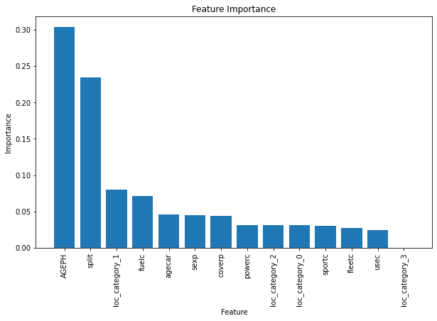

|  | feature | importance |
| --- | --- | --- |
| 9 | AGEPH | 0.303418 |
| 3 | split | 0.234851 |
| 11 | loc_category_1 | 0.080238 |
| 2 | fuelc | 0.071366 |
| 0 | agecar | 0.045997 |
| 1 | sexp | 0.044843 |
| 7 | coverp | 0.044064 |
| 8 | powerc | 0.031186 |
| 12 | loc_category_2 | 0.031053 |
| 10 | loc_category_0 | 0.030987 |
| 6 | sportc | 0.030067 |
| 5 | fleetc | 0.027815 |
| 4 | usec | 0.024114 |
| 13 | loc_category_3 | 0.000000 |

```python
get_feat_importance(xgb_freq, X_freq_train)
```

```
<sklearn.inspection._plot.partial_dependence.PartialDependenceDisplay at 0x1ff03cf1900>
```

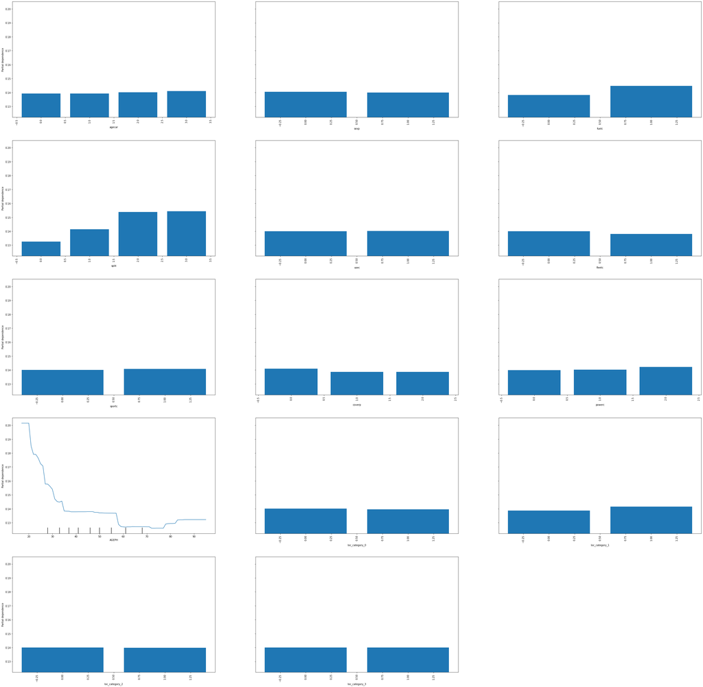

```python
fig, ax = plt.subplots(figsize=(50, 50))
plt.figure(figsize=(150, 150))
PartialDependenceDisplay.from_estimator(xgb_freq, X_freq_train,
                                        features =feat_cols,
                                        categorical_features= categorical_feat_cols,
                                        kind='average', ax=ax)
```

### 3.2 Severity preidction

Target variable is average loss per claim for the policyholder $\frac{L_i}{N_i}$,

where $N_i$ - number of claim during the period of exposure $d_i$.

```python
tmp = pd.concat([X_train, y_train], axis=1)
tmp = tmp[tmp['nbrtotc'] > 1]

X_sev_train = tmp[X_train.columns]
y_sev_train = tmp['chargtot'] / tmp['nbrtotc']
y_sev_log_train = np.log(y_sev_train)
w_sev_train = tmp['nbrtotc']
```

#### 3.2.1 Mode building

The process in analogous to the model building for frequency data. The only difference is the usage of gamma distribution for the loss, because of the distribution of the severity variable.

```python
xgb_init_sev = xgb.XGBRegressor(booster='gbtree',
                            learning_rate = 0.01,
                            objective='reg:gamma',
                            eval_metric = 'gamma-nloglik',
                            monotone_constraints = (1,0,0,0,0,0,0,0,0),
                            base_score = np.sum(y_sev_train * w_sev_train)/np.sum(w_sev_train),
                               random_state = 32)
```

```python
%time

xgb_randomsearch_sev = RandomizedSearchCV(estimator=xgb_init_sev,
                                      param_distributions=param_dict_xgb,
                                      scoring='neg_mean_gamma_deviance',
                                      n_iter=2,
                                      verbose=1,
                                      cv=5,
                                      random_state = 54321)
xgb_randomsearch_sev.fit(X_sev_train, y_sev_train, sample_weight=w_sev_train)
```

```
CPU times: total: 0 ns
Wall time: 0 ns
Fitting 5 folds for each of 2 candidates, totalling 10 fits
```

```
RandomizedSearchCV(cv=5,
                   estimator=XGBRegressor(base_score=1567.3100052612335,
                                          booster='gbtree', callbacks=None,
                                          colsample_bylevel=None,
                                          colsample_bynode=None,
                                          colsample_bytree=None,
                                          early_stopping_rounds=None,
                                          enable_categorical=False,
                                          eval_metric='gamma-nloglik',
                                          feature_types=None, gamma=None,
                                          gpu_id=None, grow_policy=None,
                                          importance_type=None,
                                          interaction_co...
                                          monotone_constraints=(1, 0, 0, 0, 0,
                                                                0, 0, 0, 0),
                                          n_estimators=100, n_jobs=None,
                                          num_parallel_tree=None,
                                          objective='reg:gamma', predictor=None, ...),
                   n_iter=2,
                   param_distributions={'alpha': [0, 0.1, 1],
                                        'colsample_bynode': [0.5, 0.75, 1],
                                        'lambda': [0, 0.1, 1],
                                        'max_depth': [1, 3, 5, 7, 9],
                                        'n_estimators': [100, 200, 300]},
                   random_state=54321, scoring='neg_mean_gamma_deviance',
                   verbose=1)
```

```python
xgb_sev = xgb_randomsearch_sev.best_estimator_
```

#### 3.2.2 Interpretation

The most important features for severity prediction are:

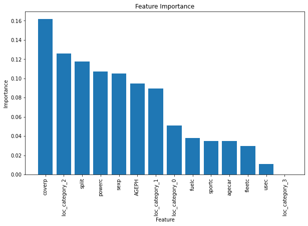

|  | feature | importance |
| --- | --- | --- |
| 7 | coverp | 0.161501 |
| 12 | loc_category_2 | 0.125928 |
| 3 | split | 0.117622 |
| 8 | powerc | 0.107198 |
| 1 | sexp | 0.105308 |
| 9 | AGEPH | 0.094510 |
| 11 | loc_category_1 | 0.089192 |
| 10 | loc_category_0 | 0.050759 |
| 2 | fuelc | 0.037972 |
| 6 | sportc | 0.034810 |
| 0 | agecar | 0.034794 |
| 5 | fleetc | 0.029694 |
| 4 | usec | 0.010712 |
| 13 | loc_category_3 | 0.000000 |

```python
get_feat_importance(xgb_sev, X_sev_train)
```

```
<sklearn.inspection._plot.partial_dependence.PartialDependenceDisplay at 0x1ff030cc040>
```

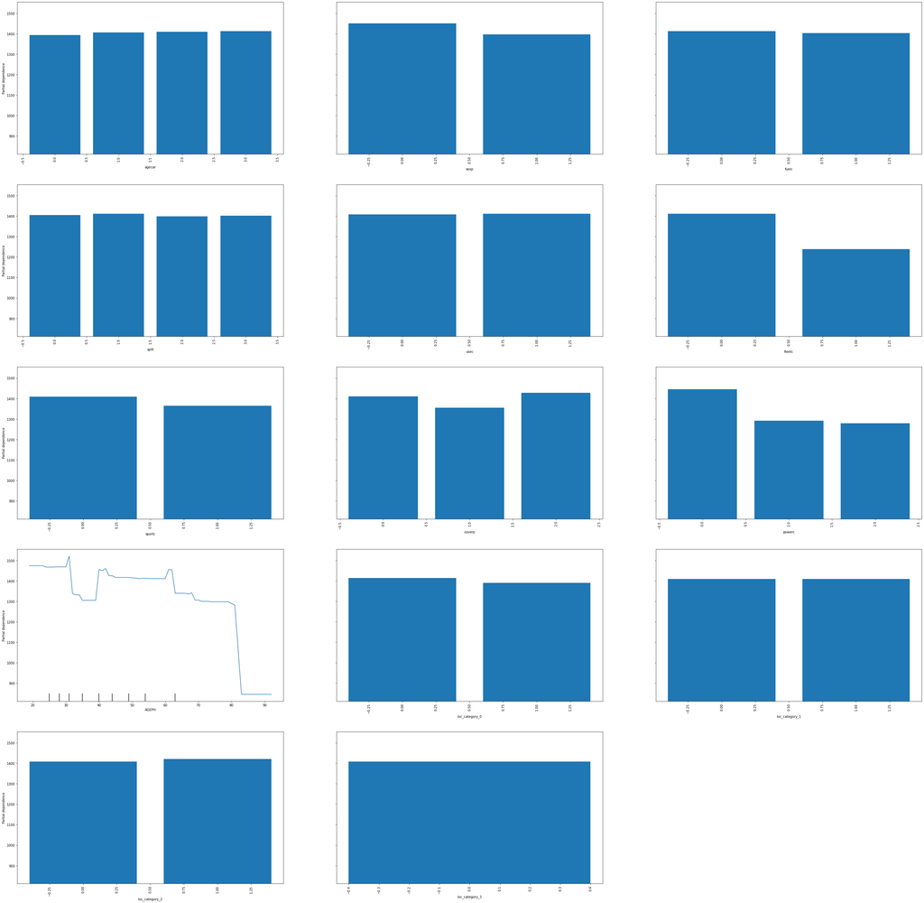

```python
fig, ax = plt.subplots(figsize=(50, 50))
plt.figure(figsize=(150, 150))
PartialDependenceDisplay.from_estimator(xgb_sev, X_sev_train,
                                        features =feat_cols,
                                        categorical_features= categorical_feat_cols,
                                        kind='average', ax=ax)
```

### 3.3 Caluclations safety demonstration

The approach followed in 'Boosting Insights in Insurance Tariff Plans with Tree-Based Machine Learning Methods' was adapted.

Observed losses, taken as the sum of $chargtot$ column are compared with technical premium $\pi_i$. $\pi_i$ is calculated in the following way:

$$\pi_{i}=E(\frac{N_i}{d_i})E(\frac{L_{i}}{N_{i}})=\hat{f} \hat{s}$$

,

where $\hat{f}$ – prediction of the frequency model, $\hat{s}$ – prediction of the severity model.

All the comparisons are made on the validation data, obtained in the previous section to see how the approach will deal with unseen data.

**XGBoost-based prediction underestimates the actual losses on 1% on the validation data.**

Henckaerts, R., Côté, M.-P., Antonio, K., & Verbelen, R. (2020). Boosting Insights in Insurance Tariff Plans with Tree-Based Machine Learning Methods. Variance, 14(1), 82-108. https://doi.org/10.21314/JOP.2020.197

```python
def compute_pred_result(X, y, model_freq, model_sev, model_name='Model', theta=None):
    total_loss = y['chargtot'].sum()
    exposure = y['expo']

    pred_freq = model_freq.predict(X)
    pred_sev = model_sev.predict(X)#tmp['chargtot'] / tmp['nbrtotc']

    tech_premium = pred_freq * pred_sev

    if theta:
        tech_premium = (1 + theta) * tech_premium



    loss_premium_fraction = total_loss / sum(tech_premium * exposure)

    return pd.DataFrame({
        'Total loss': round(total_loss),
        'Total premium': round(sum(tech_premium * exposure)),
        'Total loss/total premium': round(loss_premium_fraction, 3)
    }, index=[model_name])
```

```python
compute_pred_result(X_val, y_val, xgb_freq, xgb_sev, 'XGBoost (validation data)')
```

|  | Total loss | Total premium | Total loss/total premium |
| --- | --- | --- | --- |
| XGBoost (validation data) | 4534090 | 4487691 | 1.01 |

### 3.4 Risk loading

For calculating risk loading expected value principle will be used.

#### 3.4.1 Expected value principle

> For any $θ > 0$, where $θ$ is known as the relative security loading on the pure premium. So, the loading in the premium is $θE[PurePremium_i]$ and the expected value principle is pure premium plus the premium loading . Hence,

> $$ Premium_i = (1+\theta) PurePremium_i $$

> The biggest disadvantage of the principle, is same $\theta$ for risky and risk-free polyciholders. But as the claim histroy of each policy holder is unavailable, we can't perform risk-profiling .

*Mohammad Jamsher Ali1. (2016). Wang’s premium principle: overview and comparison with classical principles. Retrieved May 13, 2023, from https://core.ac.uk/download/pdf/79115112.pdf*

#### 3.4.2 Theta calculation

We suppose that $\theta$ is normally distributed. To calculate mean and standard deviation bootstrap was used.

```python
def bootstrap_ratios(X, y, model_freq, model_sev, n_bootstrap_samples, theta=None):
    ratios = []
    for _ in range(n_bootstrap_samples):
        # Generate random indices with replacement
        indices = np.random.choice(len(X), len(X), replace=True)

        # Create the bootstrap samples
        X_bootstrap = X.iloc[indices]
        y_bootstrap = y.iloc[indices]

        ratio = compute_pred_result(
            X_bootstrap,
            y_bootstrap,
            model_freq,
            model_sev, theta=theta)['Total loss/total premium'][0]

        ratios.append(ratio)

    return np.array(ratios)
```

```python
ratios = bootstrap_ratios(X_train, y_train, xgb_freq, xgb_sev, 100)
```

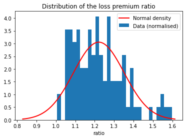

```python
np.random.seed(123)

# calculate mean and standard deviation of the data
mu, sigma = ratios.mean(), ratios.std()

# generate normal distribution with same mean and standard deviation
x = np.linspace(mu - 3*sigma, mu + 3*sigma, 100)
pdf = norm.pdf(x, mu, sigma)

# plot histogram of data and normal distribution
fig, ax = plt.subplots()
ax.hist(ratios, bins=30, density=True)
ax.plot(x, pdf, color='red', linewidth=2)
ax.set_xlabel('ratio')
ax.legend(['Normal density', 'Data (normalised)'])
ax.set_title('Distribution of the loss premium ratio')

plt.show()
```

```python
xgb_theta = stats.norm.ppf(0.95, loc=mu, scale=sigma) - 1
xgb_theta
```

```
0.4358346065422025
```

### 3.5 Final model perfomance on the test data

The following XGBoost-based model is considered as final pricing model

$$ Premium_i = (1+\theta_{xgb}) PurePremium_i $$

.

The model without risk-loading underestimates risk on 14.7%

```python
compute_pred_result(X_test, y_test, xgb_freq, xgb_sev, 'XGBoost (test data)')
```

|  | Total loss | Total premium | Total loss/total premium |
| --- | --- | --- | --- |
| XGBoost (test data) | 6431450 | 5605744 | 1.147 |

Premium of the risk-loading model is almost 20% higher that total loss.

```python
compute_pred_result(X_test, y_test, xgb_freq, xgb_sev, 'XGBoost with risk-loading(test data)', xgb_theta)
```

|  | Total loss | Total premium | Total loss/total premium |
| --- | --- | --- | --- |
| XGBoost with risk-loading(test data) | 6431450 | 8048921 | 0.799 |

#### 3.5.1 Final model probability of ruin

In this subsection the possibility of ruin (total loss > total premium), will be tested.

```python
ratios = bootstrap_ratios(X_test, y_test, xgb_freq, xgb_sev, 300, theta=xgb_theta)
```

```python
len(ratios[ratios > 1]) / 300
```

```
0.02666666666666667
```

The model ruined on less than 5% of the bootsrapped samples. This can be considered as a proof of correctness of the pricing approach.

## 4 Random forest

In this section, random forest models will be used to predict frequency and severity. Than the built models will be analyzed.

### 4.1 Frequency prediction

#### 4.1.1 Model building

Same approach as for XGBoost frequency model.

```python
param_dict_rf = {
    'n_estimators': [100, 200, 300],
    'max_depth': [5, 10, 20, None],
    'min_samples_split': [2, 5, 10],
    'min_samples_leaf': [1, 2, 4]
}

rf_init_freq = RandomForestRegressor(random_state=42)
```

```python
%time

rf_randomsearch_freq = RandomizedSearchCV(estimator=rf_init_freq,
                                      param_distributions=param_dict_rf,
                                     scoring='neg_mean_poisson_deviance',
                                      n_iter=2,
                                      verbose=1,
                                      cv=5,
                                      random_state = 54321)
rf_randomsearch_freq.fit(X_freq_train, y_freq_train, sample_weight=w_freq_train)
```

```
CPU times: total: 0 ns
Wall time: 0 ns
Fitting 5 folds for each of 2 candidates, totalling 10 fits
```

```
RandomizedSearchCV(cv=5, estimator=RandomForestRegressor(random_state=42),
                   n_iter=2,
                   param_distributions={'max_depth': [5, 10, 20, None],
                                        'min_samples_leaf': [1, 2, 4],
                                        'min_samples_split': [2, 5, 10],
                                        'n_estimators': [100, 200, 300]},
                   random_state=54321, scoring='neg_mean_poisson_deviance',
                   verbose=1)
```

```python
rf_freq = rf_randomsearch_freq.best_estimator_
```

#### 4.1.2 Interpretation

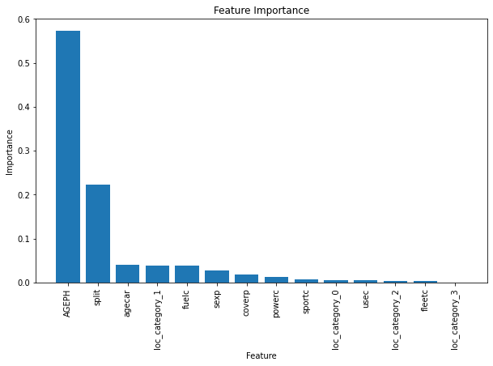

|  | feature | importance |
| --- | --- | --- |
| 9 | AGEPH | 0.572173 |
| 3 | split | 0.223164 |
| 0 | agecar | 0.040316 |
| 11 | loc_category_1 | 0.039623 |
| 2 | fuelc | 0.037870 |
| 1 | sexp | 0.028414 |
| 7 | coverp | 0.017733 |
| 8 | powerc | 0.013769 |
| 6 | sportc | 0.008015 |
| 10 | loc_category_0 | 0.006228 |
| 4 | usec | 0.004778 |
| 12 | loc_category_2 | 0.004556 |
| 5 | fleetc | 0.003359 |
| 13 | loc_category_3 | 0.000000 |

```python
get_feat_importance(rf_freq, X_freq_train)
```

```
<sklearn.inspection._plot.partial_dependence.PartialDependenceDisplay at 0x1ff031f9600>
```

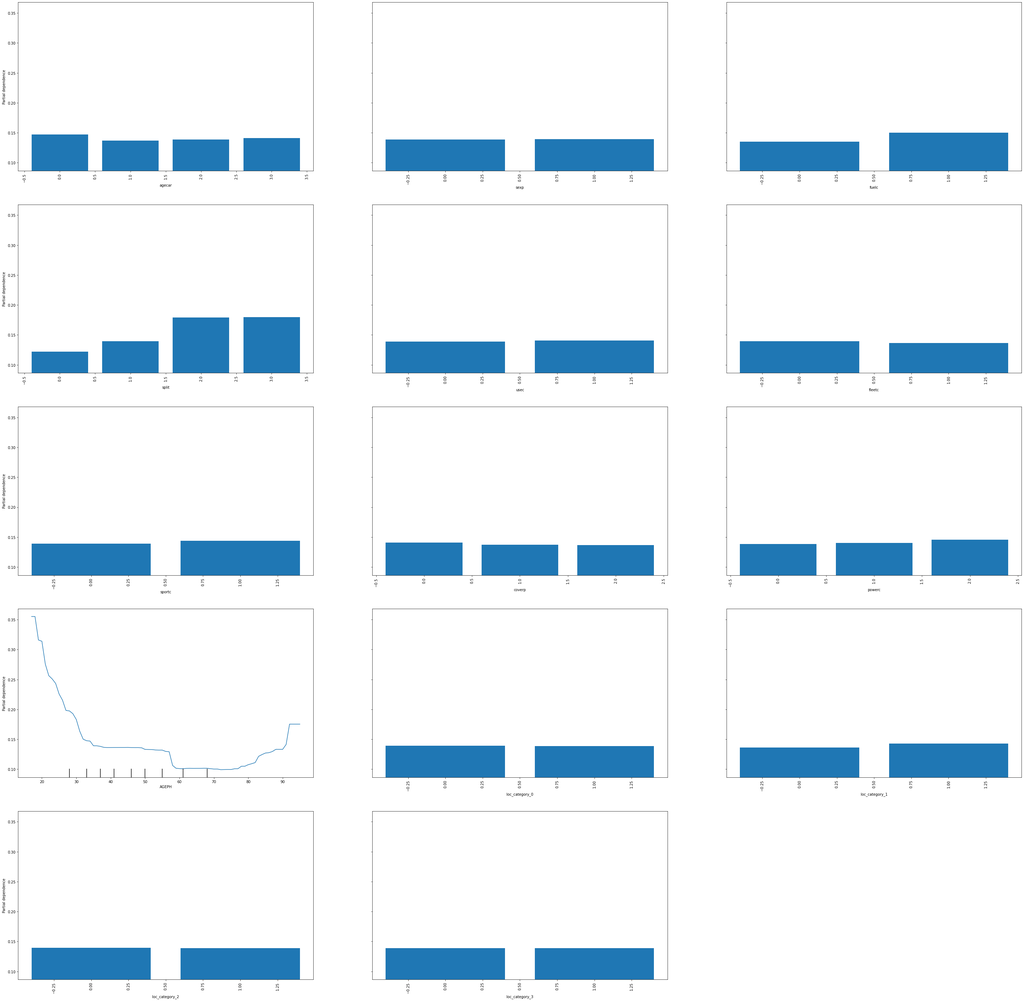

```python
fig, ax = plt.subplots(figsize=(50, 50))
plt.figure(figsize=(150, 150))
PartialDependenceDisplay.from_estimator(rf_freq, X_freq_train,
                                        features =feat_cols,
                                        categorical_features= categorical_feat_cols,
                                        kind='average', ax=ax)
```

### 4.2 Severity preidiction

#### 4.2.1 Model building

Same as for XGBoost severity model.

```python
rf_init_sev = RandomForestRegressor(random_state=42)
```

```python
%time

rf_randomsearch_sev = RandomizedSearchCV(estimator=rf_init_sev,
                                      param_distributions=param_dict_rf,
                                     scoring='neg_mean_gamma_deviance',
                                      n_iter=2,
                                      verbose=1,
                                      cv=5,
                                      random_state = 54321)
rf_randomsearch_sev.fit(X_sev_train, y_sev_train, sample_weight=w_sev_train)
```

```
CPU times: total: 0 ns
Wall time: 0 ns
Fitting 5 folds for each of 2 candidates, totalling 10 fits
```

```
RandomizedSearchCV(cv=5, estimator=RandomForestRegressor(random_state=42),
                   n_iter=2,
                   param_distributions={'max_depth': [5, 10, 20, None],
                                        'min_samples_leaf': [1, 2, 4],
                                        'min_samples_split': [2, 5, 10],
                                        'n_estimators': [100, 200, 300]},
                   random_state=54321, scoring='neg_mean_gamma_deviance',
                   verbose=1)
```

```python
rf_sev = rf_randomsearch_sev.best_estimator_
```

#### 4.2.2 Interpretation

The severity random forest model's feature importances significantly differ from the one obtained with XGBoost.

Possibly such inconsistency can be explained by randomised feature selection process of random forest

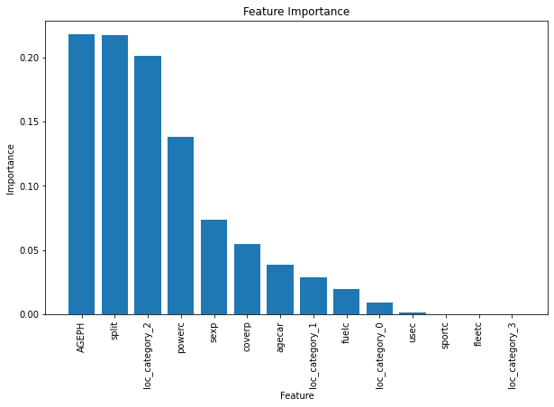

|  | feature | importance |
| --- | --- | --- |
| 9 | AGEPH | 0.217584 |
| 3 | split | 0.217455 |
| 12 | loc_category_2 | 0.201312 |
| 8 | powerc | 0.137859 |
| 1 | sexp | 0.073412 |
| 7 | coverp | 0.054568 |
| 0 | agecar | 0.038691 |
| 11 | loc_category_1 | 0.028762 |
| 2 | fuelc | 0.019474 |
| 10 | loc_category_0 | 0.009383 |
| 4 | usec | 0.001223 |
| 6 | sportc | 0.000267 |
| 5 | fleetc | 0.000009 |
| 13 | loc_category_3 | 0.000000 |

```python
get_feat_importance(rf_sev, X_sev_train)
```

```
<sklearn.inspection._plot.partial_dependence.PartialDependenceDisplay at 0x1ff0425a5f0>
```

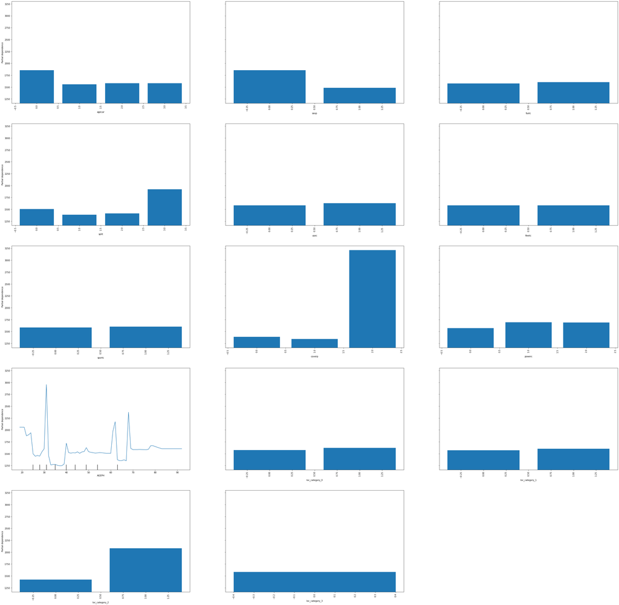

```python
fig, ax = plt.subplots(figsize=(50, 50))
plt.figure(figsize=(150, 150))
PartialDependenceDisplay.from_estimator(rf_sev, X_sev_train,
                                        features =feat_cols,
                                        categorical_features= categorical_feat_cols,
                                        kind='average', ax=ax)
```

### 4.3 Caluclation safety demonstration

For random forest models, the same approach as for XGBoost was applied. **The random forest-based prediction overestimates the actual losses on 16% on validation data**.

```python
compute_pred_result(X_val, y_val, rf_freq, rf_sev, 'Random Forest (validation data)')
```

|  | Total loss | Total premium | Total loss/total premium |
| --- | --- | --- | --- |
| Random Forest (validation data) | 4534090 | 5384800 | 0.842 |

### 4.4 Risk loading

Same approach as one used for XGBoost model is applied.

#### 4.4.1 Theta calculation

```python
ratios = ratios = bootstrap_ratios(X_train, y_train, rf_freq, rf_sev, 100)
```

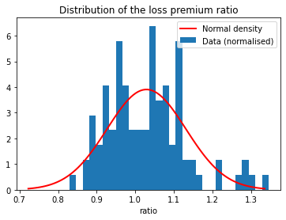

```python
np.random.seed(123)

# calculate mean and standard deviation of the data
mu, sigma = ratios.mean(), ratios.std()

# generate normal distribution with same mean and standard deviation
x = np.linspace(mu - 3*sigma, mu + 3*sigma, 100)
pdf = norm.pdf(x, mu, sigma)

# plot histogram of data and normal distribution
fig, ax = plt.subplots()
ax.hist(ratios, bins=30, density=True)
ax.plot(x, pdf, color='red', linewidth=2)
ax.set_xlabel('ratio')
ax.legend(['Normal density', 'Data (normalised)'])
ax.set_title('Distribution of the loss premium ratio')

plt.show()
```

```python
rf_theta = stats.norm.ppf(0.95, loc=mu, scale=sigma) - 1
rf_theta
```

```
0.19705107508099529
```

### 4.5 Final model perfomance on the test data

The following random forest-based model is considered final pricing model

$$ Premium_i = (1+\theta_{rf}) PurePremium_i $$

.

The model without risk-loading overestimates risk on 4%.

```python
compute_pred_result(X_test, y_test, rf_freq, rf_sev, 'XGBoost (test data)')
```

|  | Total loss | Total premium | Total loss/total premium |
| --- | --- | --- | --- |
| XGBoost (test data) | 6431450 | 6693190 | 0.961 |

As expected introducing risk-loading only increases overestimation.

```python
compute_pred_result(X_test, y_test, rf_freq, rf_sev, 'XGBoost (test data)', rf_theta)
```

|  | Total loss | Total premium | Total loss/total premium |
| --- | --- | --- | --- |
| XGBoost (test data) | 6431450 | 8012090 | 0.803 |

#### 4.5.1 Final model probability of ruin

In this subsection the possibility of ruin (total loss > total premium), will be tested.

```python
ratios = bootstrap_ratios(X_test, y_test, rf_freq, rf_sev, 300, theta=rf_theta)
```

```python
len(ratios[ratios > 1]) / 300
```

```
0.02666666666666667
```

The model ruined on less than 5% of the bootsrapped samples. This can be considered as a proof of correctness of the pricing approach.